# Data Science Pipeline Tutorial

## Introduction

Welcome to this data science pipeline tutorial! We'll be going over the basics of setting up, getting data, tidying the data, managing missing values, data analysis and visualization, and hypothesis testing.

In this tutorial, we'll be using data on unemployment rates and median salaries for different college majors. The dataset is also organized into three categories: graduate students, non-graduate students, and total students.

Picking a college major is hard, there's so many things to consider! For some people, it's important to consider how financially stable and how easily one could potentially find a job with a degree in a certain major. In addition to this, some people don't know whether or not they should attend graduate school. Will they more easily find a job and earn more money if they become a graduate student?

Within this tutorial, we hope to answer these two questions:

1. How does college major influence employment and how much money one makes?
2. What's the relationship between graduate student salaries and non-graduate student salaries?

## Setting Up

First, we will need to import some packages for this tutorial. These packages will help us more easily move, modify, and change data in the forms of arrays, tables, graphs, and more! Specifically, we'll be using pandas to organize our data in a dataframe and we'll use matplotlib to plot some graphs.

```python
import pandas as pd
import seaborn as sns
import numpy as np
import matplotlib.pyplot as plt
from sklearn import datasets, linear_model
import statsmodels.api as sm
```

## Getting the Data

We'll be getting our data from Kaggle: https://www.kaggle.com/tunguz/college-majors?select=recent-grads.csv. Specifically, we'll be using the "all-ages.csv" and "grad_students.cvs" files that can be easily downloaded from the website.

For this section, we're going to read these cvs files into Pandas dataframes.

```python
# Reads all-ages.cvs into a dataframe and prints the dataframe.
df1 = pd.read_csv (r'/home/jovyan/notebooks/all-ages.csv')
df1 = df1.sort_values("Major_code", ascending=True)
df1.head()
```

|  | Major_code | Major | Major_category | Total | Employed | Employed_full_time_year_round | Unemployed | Unemployment_rate | Median | P25th | P75th |
| --- | --- | --- | --- | --- | --- | --- | --- | --- | --- | --- | --- |
| 0 | 1100 | GENERAL AGRICULTURE | Agriculture & Natural Resources | 128148 | 90245 | 74078 | 2423 | 0.026147 | 50000 | 34000 | 80000.0 |
| 1 | 1101 | AGRICULTURE PRODUCTION AND MANAGEMENT | Agriculture & Natural Resources | 95326 | 76865 | 64240 | 2266 | 0.028636 | 54000 | 36000 | 80000.0 |
| 2 | 1102 | AGRICULTURAL ECONOMICS | Agriculture & Natural Resources | 33955 | 26321 | 22810 | 821 | 0.030248 | 63000 | 40000 | 98000.0 |
| 3 | 1103 | ANIMAL SCIENCES | Agriculture & Natural Resources | 103549 | 81177 | 64937 | 3619 | 0.042679 | 46000 | 30000 | 72000.0 |
| 4 | 1104 | FOOD SCIENCE | Agriculture & Natural Resources | 24280 | 17281 | 12722 | 894 | 0.049188 | 62000 | 38500 | 90000.0 |

```python
# Reads grad-students.cvs into a dataframe and prints the dataframe.
df2 = pd.read_csv (r'/home/jovyan/notebooks/grad-students.csv')
df2 = df2.sort_values(["Major_code"], ascending=True)
df2.head()
```

|  | Major_code | Major | Major_category | Grad_total | Grad_sample_size | Grad_employed | Grad_full_time_year_round | Grad_unemployed | Grad_unemployment_rate | Grad_median | ... | Nongrad_total | Nongrad_employed | Nongrad_full_time_year_round | Nongrad_unemployed | Nongrad_unemployment_rate | Nongrad_median | Nongrad_P25 | Nongrad_P75 | Grad_share | Grad_premium |
| --- | --- | --- | --- | --- | --- | --- | --- | --- | --- | --- | --- | --- | --- | --- | --- | --- | --- | --- | --- | --- | --- |
| 42 | 1100 | GENERAL AGRICULTURE | Agriculture & Natural Resources | 44306 | 764 | 28930 | 23024 | 874 | 0.029325 | 68000.0 | ... | 123984 | 86631 | 72409 | 2352 | 0.026432 | 50000.0 | 34000 | 80000.0 | 0.263272 | 0.360000 |
| 7 | 1101 | AGRICULTURE PRODUCTION AND MANAGEMENT | Agriculture & Natural Resources | 17488 | 386 | 13104 | 11207 | 473 | 0.034838 | 67000.0 | ... | 89169 | 71781 | 61335 | 1869 | 0.025377 | 55000.0 | 38000 | 80000.0 | 0.163965 | 0.218182 |
| 62 | 1102 | AGRICULTURAL ECONOMICS | Agriculture & Natural Resources | 14800 | 305 | 10592 | 8768 | 216 | 0.019985 | 80000.0 | ... | 33049 | 25557 | 22496 | 734 | 0.027918 | 63000.0 | 40000 | 99000.0 | 0.309306 | 0.269841 |
| 79 | 1103 | ANIMAL SCIENCES | Agriculture & Natural Resources | 56807 | 1335 | 47755 | 39047 | 596 | 0.012327 | 70300.0 | ... | 94910 | 74896 | 61629 | 3101 | 0.039758 | 48000.0 | 32000 | 75000.0 | 0.374427 | 0.464583 |
| 84 | 1104 | FOOD SCIENCE | Agriculture & Natural Resources | 14521 | 266 | 10857 | 8074 | 370 | 0.032956 | 72000.0 | ... | 22853 | 16298 | 12431 | 681 | 0.040108 | 63000.0 | 40000 | 92000.0 | 0.388532 | 0.142857 |

5 rows × 22 columns

## Tidying the Data

Time to tidy our data! Tidying our data refers to organizing our data in a way that makes it easy to run analyses on. Since we have our data in a two Pandas dataframe, we are going to merge them into one dataframe. By having all of our data in one dataframe, we only need to keep track of one dataframe— making it easier to compare values. We'll also tidy our data by removing unwanted columns and rows from our dataframe.

For more information on how to manage Pandas dataframes, please refer to this link: https://pandas.pydata.org/docs/reference/api/pandas.DataFrame.html

```python
# Merges the two dataframes based on "Major_code" because both dataframes contain the same set of major_codes that
# distinguish one rows from another.
# Prints the resulting dataframe.
df = pd.merge(df1, df2, on='Major_code')
df.head()
```

|  | Major_code | Major_x | Major_category_x | Total | Employed | Employed_full_time_year_round | Unemployed | Unemployment_rate | Median | P25th | ... | Nongrad_total | Nongrad_employed | Nongrad_full_time_year_round | Nongrad_unemployed | Nongrad_unemployment_rate | Nongrad_median | Nongrad_P25 | Nongrad_P75 | Grad_share | Grad_premium |
| --- | --- | --- | --- | --- | --- | --- | --- | --- | --- | --- | --- | --- | --- | --- | --- | --- | --- | --- | --- | --- | --- |
| 0 | 1100 | GENERAL AGRICULTURE | Agriculture & Natural Resources | 128148 | 90245 | 74078 | 2423 | 0.026147 | 50000 | 34000 | ... | 123984 | 86631 | 72409 | 2352 | 0.026432 | 50000.0 | 34000 | 80000.0 | 0.263272 | 0.360000 |
| 1 | 1101 | AGRICULTURE PRODUCTION AND MANAGEMENT | Agriculture & Natural Resources | 95326 | 76865 | 64240 | 2266 | 0.028636 | 54000 | 36000 | ... | 89169 | 71781 | 61335 | 1869 | 0.025377 | 55000.0 | 38000 | 80000.0 | 0.163965 | 0.218182 |
| 2 | 1102 | AGRICULTURAL ECONOMICS | Agriculture & Natural Resources | 33955 | 26321 | 22810 | 821 | 0.030248 | 63000 | 40000 | ... | 33049 | 25557 | 22496 | 734 | 0.027918 | 63000.0 | 40000 | 99000.0 | 0.309306 | 0.269841 |
| 3 | 1103 | ANIMAL SCIENCES | Agriculture & Natural Resources | 103549 | 81177 | 64937 | 3619 | 0.042679 | 46000 | 30000 | ... | 94910 | 74896 | 61629 | 3101 | 0.039758 | 48000.0 | 32000 | 75000.0 | 0.374427 | 0.464583 |
| 4 | 1104 | FOOD SCIENCE | Agriculture & Natural Resources | 24280 | 17281 | 12722 | 894 | 0.049188 | 62000 | 38500 | ... | 22853 | 16298 | 12431 | 681 | 0.040108 | 63000.0 | 40000 | 92000.0 | 0.388532 | 0.142857 |

5 rows × 32 columns

```python
# Displays all the possible columns of our dataframe so that we can pick out the columns that we want to keep.
print(df.columns)
```

```
Index(['Major_code', 'Major_x', 'Major_category_x', 'Total', 'Employed',
       'Employed_full_time_year_round', 'Unemployed', 'Unemployment_rate',
       'Median', 'P25th', 'P75th', 'Major_y', 'Major_category_y', 'Grad_total',
       'Grad_sample_size', 'Grad_employed', 'Grad_full_time_year_round',
       'Grad_unemployed', 'Grad_unemployment_rate', 'Grad_median', 'Grad_P25',
       'Grad_P75', 'Nongrad_total', 'Nongrad_employed',
       'Nongrad_full_time_year_round', 'Nongrad_unemployed',
       'Nongrad_unemployment_rate', 'Nongrad_median', 'Nongrad_P25',
       'Nongrad_P75', 'Grad_share', 'Grad_premium'],
      dtype='object')
```

```python
# Updates the dataframe to select only the columns we desire (we will be only looking at Majors, Major Categories,
# Total Students, Unemployment Rate for Total Students, Median Salary for Total Students, Graduate Unemployment
# Rate, Graduate Median Salary, Non-graduate unemployment rate, and Nongraduate Median Salary).
df = df[["Major_x", "Major_category_x", "Total", "Unemployment_rate", "Median", "Grad_unemployment_rate",
         "Grad_median", "Nongrad_unemployment_rate", "Nongrad_median"]]
```

```python
# Displays current types of each column in the dataframe to see if there are any inconsistencies.
df.dtypes
```

```
Major_x                       object
Major_category_x              object
Total                          int64
Unemployment_rate            float64
Median                         int64
Grad_unemployment_rate       float64
Grad_median                  float64
Nongrad_unemployment_rate    float64
Nongrad_median               float64
dtype: object
```

```python
# Converts the "Total" and "Median" columns into floats because from above, we saw that some columns
# were int64 instead of float64 (making these types consistent will make it easier for float comparisons later).
df["Total"] = df["Total"].astype(float)
df["Median"] = df["Median"].astype(float)
```

## Missing Data

Checking for missing data is very important! We don't want our later results to give us problems because of missing values. To deal with these missing values, we can either replace or delete them. In our case, because there is no clear relationship between different rows or column categories, it is not easy to assume and replace missing values. Instead, we will delete any possible missing values.

First, we will see if any value in our dataframe is NaN. NaN is how the Pandas library signifies missing or null values.

```python
# Checks for NaNs in our dataframe.
is_NaN = df.isnull()
rows_with_NaN = df[is_NaN.any(axis=1)]
print(rows_with_NaN)
```

```
Empty DataFrame
Columns: [Major_x, Major_category_x, Total, Unemployment_rate, Median, Grad_unemployment_rate, Grad_median, Nongrad_unemployment_rate, Nongrad_median]
Index: []
```

From the code above, we see that there are no rows with any NaNs. Because we have no NaNs, we don't need to modify our dataframe for NaNs. However, there can be other forms of missing data. In this case, missing data in our dataframe can be represented by values of 0.0 for all of our type-float columns. If employment rates, salary medians, or number of students have the value of 0.0, that would mess up our analysis. The 0.0s in our data could interfere with calculations in our analysis, causing inaccuracy. Therefore, we consider 0.0s missing data, and we will remove rows containing them.

```python
# Checks to make sure every column in the dataframe does not contain 0.0 values.
# Prints the column name along with "true" or "false", where "true" if there are no 0.0 values in that column and
# "false" if there are 0.0 values in that column.
for column in df:
    if df[column].dtypes == float:
        print(column + " contains value 0.0: " + str((df[column] != 0.0).all()))
```

[output not shown]

```python
# From the printed results above, we see that there are three columns that contain 0.0 values: "Unemployment_rate",
# "Grad_Unemployment_rate", and "Nongrad_unemployment_rate".
# Updates the previous dataframe columns so that they no longer contain the value 0.0.
df = df[df.Unemployment_rate != 0.0]
df = df[df.Grad_unemployment_rate != 0.0]
df = df[df.Nongrad_unemployment_rate != 0.0]
```

## Data Analysis and Visualization

Finally after our data is organized and clean, we can start analyzing our data. In this section, we'll focus on finding patterns in our data through visualizations like bar graphs and a correlation matrix.

We will work on answering our first question: How does college major influence employment and how much money one makes? To answer this question, we'll create a bar graph of all college majors against average unemployment rate. Then, we'll create a bar graph of all the college majors against average median salary. We will be using matplotlib to create different graphs.

Click this link for documentation on different matplotlib functionality in Python: https://matplotlib.org/stable/api/pyplot_summary.html

```python
# Creates an array of the unique major categories.
# Because our data includes many specific types of major, it will be hard to analyze. So, we will instead use the
# groupings of big major categories to represent certain majors.
major_category = df["Major_category_x"].values
data = []

# Iterates through every unique major category and locates the rows in the dataframe with the current major category.
# Averages the unemployment rate for all of the located rows and stores that value with its corresponding
# major category.
for major in major_category:
    selected_data = df.loc[df["Major_category_x"] == major]
    total = len(selected_data)
    average_unemployment = selected_data["Unemployment_rate"].sum()/total
    data.append([major, average_unemployment])

# Sorts a temporary dataframe by average unemployment rate, so that the lowest average unemployment rate is shown
# the highest on the horizontal bar graph.
df_major_unemployment = pd.DataFrame(data, columns = ["Major_category", "Unemployment_rate"])
df_major_unemployment = df_major_unemployment.sort_values("Unemployment_rate", ascending=False)
```

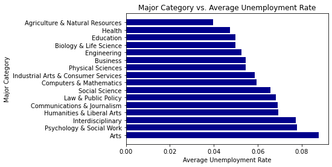

```python
# Plots a horizontal bar graph of Major Category vs. Average Unemployment Rate using matplotlib.
major_category = df_major_unemployment["Major_category"].values
unemployment_rate = df_major_unemployment["Unemployment_rate"].values

fig = plt.figure()
plt.barh(major_category, unemployment_rate, color="darkblue")
plt.ylabel("Major Category")
plt.xlabel("Average Unemployment Rate")
plt.title("Major Category vs. Average Unemployment Rate")
plt.show()
```

Analysis: We can see from the horizontal bar graph above that college major categories is on the y-axis and that average unemployment rate is on the x-axis. The smaller the average unemployment rate is, the better it is for someone to find a job having that major. From this bar graph, our data tells us that Arts has the highest unemployment rate at 0.09. So, it may be the case that it will be harder to be employed majoring in Art. From the bar graph we can also learn that Agriculture & Natural Resources (average unemployment rate 0.04) and Health (average unemployment rate 0.05) appear most promising in terms of getting employed. From average unemployment rate 0.04 to average unemployment rate 0.09, it appears that a major can have an influence on average unemployment rate considering all else is consistent.

However, it's important to note that there are lots of factors that go into employment; this includes the number of people applying, skill level, and more. But overall, it's nice to note that Agriculture & Natural Resources and Health have a high employment rate compared to other majors. Some people may find it useful to know this information when they're choosing a major. In addition, one can look at the list of majors on the y-axis and see how the major they're interested in compares to other majors in terms of average unemployment rate.

Now, let's move onto analyzing all the college majors against average median salary.

```python
# Like before, we will again create an array of the unique major categories. We will use this grouping of big
# major categories to represent certain majors.
major_category = df["Major_category_x"].values
data = []

# Iterates through every unique major category and locates the rows in the dataframe with the current major category.
# Averages the median salary for all of the located rows and stores that value with its corresponding
# major category.
for major in major_category:
    selected_data = df.loc[df["Major_category_x"] == major]
    total = len(selected_data)
    average_salary = selected_data["Median"].sum()/total
    data.append([major, average_salary])

# Sorts a temporary dataframe by average median salary, so that the highest average median salary is shown the highest
# on the horizontal bar graph.
df_major_salary = pd.DataFrame(data, columns = ["Major_category", "Salary"])
df_major_salary = df_major_salary.sort_values("Salary", ascending=True)
```

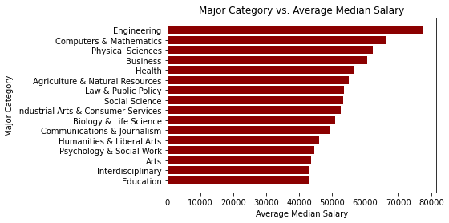

```python
# Plots a horizontal bar graph of Major Category vs. Average Median Salary using matplotlib.
major_category = df_major_salary["Major_category"].values
salary = df_major_salary["Salary"].values

fig = plt.figure()
plt.barh(major_category, salary, color="darkred")
plt.ylabel("Major Category")
plt.xlabel("Average Median Salary")
plt.title("Major Category vs. Average Median Salary")
plt.show()
```

Analysis: The horizontal bar graph above shows college major categories on the y-axis and average median salary on the x-axis. The higher the average median salary is, the better it is for someone to find a job having that major. From this bar graph, our data tells us that Engineering has the highest median salary at almost 80,000 dollars. With such a high average median salary compared to other majors, this may be a big incentive for people to want to major in Engineering. On the other side of the spectrum, Education and Interdisciplinary majors have the lowest average median salaries at around 42,000 dollars each. With the lowest average median salaries, some people may decide that they may not want to pursue those majors. From average median salaries of 42,000 dollars to average median salaries of 80,000 dollars, it appears that a major can definitely have an influence on average median salary considering all else is consistent.

Again, it's important to note that there are lots of factors that go into choosing a major. Even though a high salary seems promising for people choosing a major, it may be the case that the major requires more work and might be more boring depending on the person. So, one should not base how to choose a major on solely the average median salary. It's also important to consider different aspects of earning a salary— it is not solely dependent on one's major, it includes worth ethic, projects, and experience. But for those people that are encouraged by a challenge and really want a high salary, this data would encourage them to pick an engineering major. Also, for those who are interested in seeing how one major compares to another in terms of average median salary, this bar graph is a great visualization!

Next, we will be looking at graduate vs. nongraduate student unemployment rates and median salaries.

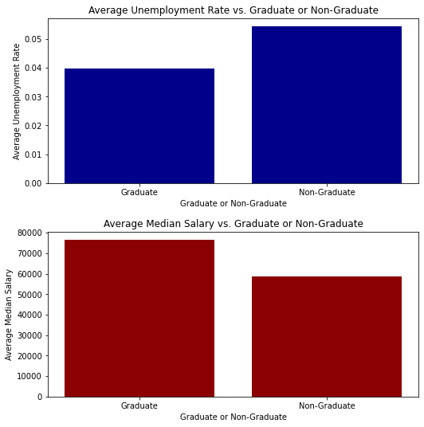

```python
# Finds the mean values across all majors for graduate unemployment rate, graduate median salary,
# non-graduate unemployment rate, and non-graduate median salary.
grad_unemployment = df["Grad_unemployment_rate"].mean()
nongrad_unemployment = df["Nongrad_unemployment_rate"].mean()
grad_salary = df["Grad_median"].mean()
nongrad_salary = df["Nongrad_median"].mean()

# Plots bar graphs on two subplots using matplotlib.
data_grad_nongrad_salary = [[grad_unemployment],
[nongrad_unemployment]]
data_grad_nongrad_salary = [[grad_unemployment],
[nongrad_unemployment]]
fig, axs = plt.subplots(2,figsize=(8,8))
fig.tight_layout(pad = 4.0)

# The first plot is of Average Unemployment Rate vs. Graduate or Non-Graduate.
axs[0].bar(["Graduate", "Non-Graduate"], [grad_unemployment, nongrad_unemployment], color="darkblue")
axs[0].set_xlabel("Graduate or Non-Graduate")
axs[0].set_ylabel("Average Unemployment Rate")
axs[0].set_title("Average Unemployment Rate vs. Graduate or Non-Graduate")

# The second plot is of Average Median Salary vs. Graduate or Non-Graduate.
axs[1].bar(["Graduate", "Non-Graduate"], [grad_salary, nongrad_salary], color="darkred")
axs[1].set_xlabel("Graduate or Non-Graduate")
axs[1].set_ylabel("Average Median Salary")
axs[1].set_title("Average Median Salary vs. Graduate or Non-Graduate")
```

From the first plot of Average Unemployment Rate vs. Graduate or Non-Graduate, we can see that graduate students have a lower average unemployment rate at 0.04 whereas non-graduate students have a higher average unemployment rate at 0.055. From this, it may be reasonable to believe that becoming a graduate student is better in terms of getting employed assuming all else is constant. However, we should consider that the average unemployment rate of 0.04 may not be significantly better than 0.055 considering that graduate students must spend more years and money of their lives studying compared to non-graduate students.

From the second plot of Average Median Salary vs. Graduate or Non-Graduate, the bar graph shows that graduate students earn higher average median salary of 75,000 dollars compared to non-graduate students, who earn an average median salary of 60,000. So, it may be reasonable to assume that becoming a graduate student may be a viable option if one desires to have a higher salary. But in the end, salary is dependent on a lot of things like experience and knowledge— not just dependent on being a graduate student. Becoming a graduate student could probably help with experience and knowledge, but to be more confident we would have to do a whole different analysis.

Overall, from this data, it appears that graduate students have an advantage over non-graduate students when it comes to employment and salaries.

Let's now take a look at our second question: What's the relationship between graduate student salaries and non-graduate student salaries? To begin answering this question, we'll look at a correlation matrix to see how the categories Graduate Unemployment Rate, Graduate Median Salary, Non-graduate Unemployment Rate, and Non-graduate Median Salary may relate to each other.

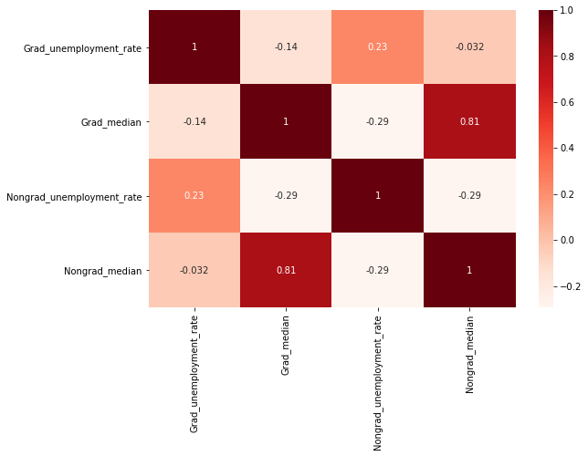

```python
# Creates a correlation matrix of the four categories.
df_grad_nongrad = df[["Grad_unemployment_rate", "Grad_median", "Nongrad_unemployment_rate", "Nongrad_median"]]
plt.figure(figsize=(9,6))
sns.heatmap(df_grad_nongrad.corr(), annot=True, cmap='Reds')
plt.show()
```

From the correlation map above, the darker reds show a higher correlation between two categories while lighter colors show a lower correlation between two categories. If you were looking at the numbers, the numbers closer to -1 and 1 show higher correlations as well. It's interesting to see that Graduate Median Salary appears to have a high correlation with Nongraduate Median Salary with the correlation coefficient of 0.81. Let's investigate this relationship more with some hypothesis testing next!

## Hypothesis Testing

What is hypothesis testing? Well, in this case, it's statistical method that will helps us determine whether or not there is a linear relationship between Nongraduate Median Salary and Graduate Median Salary. But generically, hypothesis testing is a statistical inference method that will help us draw conclusions about a population given data randomly sampled from that population at a specific significance level. For more information on hypothesis testing (including information on signficant value, null hypotheses, and alternate hypothesis), you can click on this link: https://www.ahajournals.org/doi/10.1161/CIRCULATIONAHA.105.586461

For this tutorial, we'll be using a significance level of 0.05, which is denoted 𝛼=0.05.

The null hypothesis: 𝐻𝑜 = There is no linear relationship between Nongraduate Median Salary and Graduate Median Salary.

The alternate hypothesis: 𝐻𝑎 = There is a linear relationship between Nongraduate Median Salary and Graduate Median Salary.

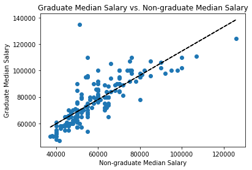

```python
# Graphs a scatterplot of Graduate Median Salary vs. Non-graduate Median Salary for all the different majors,
# including a fitted line through the points.
x = df["Nongrad_median"].to_numpy()
y = df["Grad_median"].to_numpy()
coef = np.polyfit(x, y, 1)
poly1d_fn = np.poly1d(coef)

plt.plot(df["Nongrad_median"], df["Grad_median"], 'o', x, poly1d_fn(x), '--k')
plt.xlabel("Non-graduate Median Salary")
plt.ylabel("Graduate Median Salary")
plt.title("Graduate Median Salary vs. Non-graduate Median Salary")
```

```python
# Uses Scikit-Learn to fit a linear regression line on Graduate Median Salary and Non-graduate Median Salary.
# Prints the linear regression line.
x = (df.loc[:,"Nongrad_median"]).values.reshape(-1, 1)
y = (df.loc[:,"Grad_median"]).values.reshape(-1, 1)
reg = linear_model.LinearRegression().fit(x, y)

print("Graduate Median Salary = " + str(reg.coef_[0][0]) + "(Nongraduate Median Salary) + " + str(reg.intercept_[0]))
```

```
Graduate Median Salary = 0.9141537272013098(Nongraduate Median Salary) + 23218.01148011165
```

The scatterplot of Graduate Median Salary vs. Non-graduate Median Salary shows a linear relationship between Graduate Median Salary and Non-graduate Median Salary with a few outliers. As Non-graduate Median Salary increases, it appears that Graduate Median Salary increases. And from the linear regression equation: for every increase in Nongraduate Median Salary, Graduate Median Salary increases by 0.914. However, before we come to conclusions that Graduate Median Salary and Non-graduate Median Salary are linearly related, we must complete our hypothesis test.

```python
# Prints a summary of the relationship between Graduate Median Salary and Non-graduate Median Salary from
# statsmodel library. This summary tabel will help us identify the p-values of the regression coefficient.
X2 = sm.add_constant(x)
est = sm.OLS(y, X2)
est2 = est.fit()
print(est2.summary())
```

```
                            OLS Regression Results
==============================================================================
Dep. Variable:                      y   R-squared:                       0.657
Model:                            OLS   Adj. R-squared:                  0.655
Method:                 Least Squares   F-statistic:                     322.4
Date:                Mon, 17 May 2021   Prob (F-statistic):           6.25e-41
Time:                        05:40:34   Log-Likelihood:                -1804.6
No. Observations:                 170   AIC:                             3613.
Df Residuals:                     168   BIC:                             3619.
Df Model:                           1
Covariance Type:            nonrobust
==============================================================================
                 coef    std err          t      P>|t|      [0.025      0.975]
------------------------------------------------------------------------------
const       2.322e+04   3072.385      7.557      0.000    1.72e+04    2.93e+04
x1             0.9142      0.051     17.956      0.000       0.814       1.015
==============================================================================
Omnibus:                      109.597   Durbin-Watson:                   1.561
Prob(Omnibus):                  0.000   Jarque-Bera (JB):              986.747
Skew:                           2.247   Prob(JB):                    5.38e-215
Kurtosis:                      13.914   Cond. No.                     2.44e+05
==============================================================================

Notes:
[1] Standard Errors assume that the covariance matrix of the errors is correctly specified.
[2] The condition number is large, 2.44e+05. This might indicate that there are
strong multicollinearity or other numerical problems.
```

Given the information from the summary table, we see that the p-value of the Nongraduate Median Salary coefficient is 0.0. At the 𝛼=0.05 significance level, the p-value 0.0 is less than 𝛼. Therefore, we reject the null hypothesis of no linear relationship between Graduate Median Salary and Nongraduate Median Salary. So, there is a linear relationship between Graduate Median Salary and Nongraduate Median Salary. In this case, we cannot conclude (nor would it be reasonable to assume) that an increase in Nongraduate Median Salary causes an increase in Graduate Median Salary.

## Conclusion

Through the data science pipeline, we were able to develop answers to both of our initial questions. From analyzing different graphs, we discovered that specific majors like Agriculture & Natural Resources may be pursued if people want a higher chance of employment. In addition, people may pursue an Engineering major if they're enticed by the high average median salaries Engineering majors get compared to other majors. With hypothesis testing, we were able to conclude that graduate student median salary and non-graduate student median salary have a positive linear relationship. To dive deeper into this linear relationship, we could do machine learning for another tutorial.

I hope that from this tutorial, you have learned a way to take advantage of data to come to useful conclusions!

You can find amazing datasets at these websites to do your own data analysis:

1. Datasets from the government, https://www.data.gov/
2. Datasets from Microsoft, https://azure.microsoft.com/en-us/services/open-datasets/catalog/
3. Datasets from Kraggle, https://www.kaggle.com/